# IE48B - HW3

Alihan Zer

12 12 2021

In this homework, we are expected to compare NN-Classifier methods as well as performing parameter tuning. To do so, I have worked on 5 different datasets. These are ArrowHead, ECG200, Ham, Plane, and Trace.

In order to make computaions later, first we need to create new datasets that holds distances for each method.

# Pipeline

The pipeline can be categorized as the following.

KNN, Euc, k = 1 KNN, Euc, k = 3 KNN, Euc, k = 5

KNN, DTW, k = 1 KNN, DTW, k = 3 KNN, DTW, k = 5

KNN, DTW, Sakoe, window = 10 ,k = 1 KNN, DTW, Sakoe, window = 10 ,k = 3 KNN, DTW, Sakoe, window = 10 ,k = 5

KNN, DTW, Sakoe, window = 20 ,k = 1 KNN, DTW, Sakoe, window = 20 ,k = 3 KNN, DTW, Sakoe, window = 20 ,k = 5

KNN, DTW, Itakura, window = 10 ,k = 1 KNN, DTW, Itakura, window = 10 ,k = 3 KNN, DTW, Itakura, window = 10 ,k = 5

KNN, DTW, Itakura, window = 20 ,k = 1 KNN, DTW, Itakura, window = 20 ,k = 3 KNN, DTW, Itakura, window = 20 ,k = 5

KNN, LCSS, epsilon = 0.05, k = 1 KNN, LCSS, epsilon = 0.05, k = 3 KNN, LCSS, epsilon = 0.05, k = 5

KNN, LCSS, epsilon = 0.1, k = 1 KNN, LCSS, epsilon = 0.1, k = 3 KNN, LCSS, epsilon = 0.1, k = 5

KNN, ERP, gap = 0.5, k = 1 KNN, ERP, gap = 0.5, k = 3 KNN, ERP, gap = 0.5, k = 5

KNN, ERP, gap = 1, k = 1 KNN, ERP, gap = 1, k = 3 KNN, ERP, gap = 1, k = 5

# Arrow Head

```r
traindata = traindata_reader('ArrowHead')
trainclass = trainclass_reader('ArrowHead')
```

## Visualization

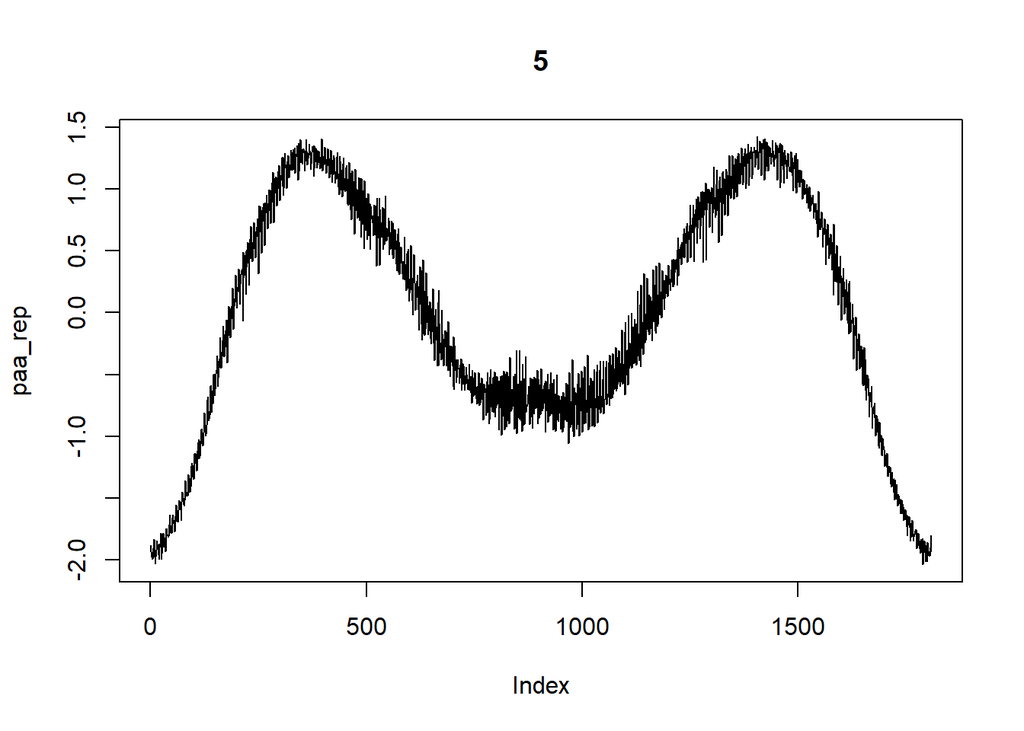

```r
paa(1, 5, traindata)
```

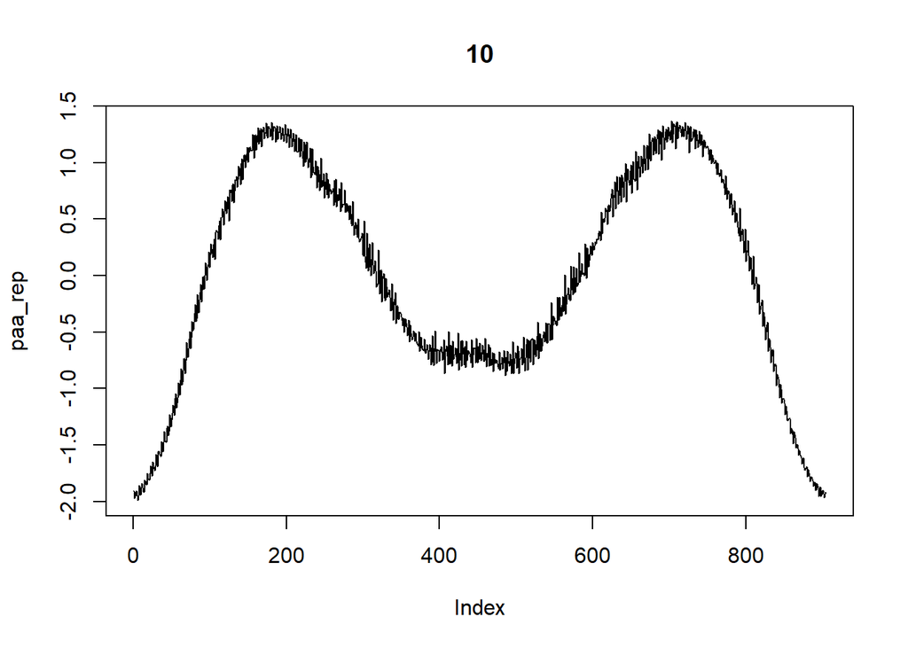

```r
paa(1, 10, traindata)
```

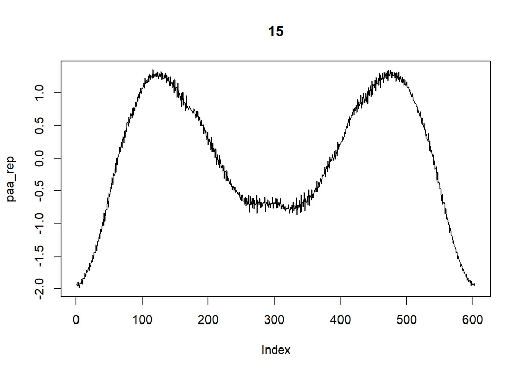

```r
paa(1, 15, traindata)
```

```r
set.seed(2017402156)
nof_rep=5
n_fold=10
cv_indices=generateCVRuns(trainclass, ntimes =nof_rep, nfold = n_fold,
                          leaveOneOut = FALSE, stratified = TRUE)

arrow_cv_indices = cv_indices

dist_folder=sprintf('%s/distances',dist_path)
dist_files=list.files(dist_folder, full.names=T)


dist_files_ArrowHead = dist_files[1:10]
dist_files_ECG200 = dist_files[11:20]
dist_files_Ham = dist_files[21:30]
dist_files_Plane = dist_files[31:40]
dist_files_Trace = dist_files[41:50]
```

```r
arrowhead_table = tablemaker(dist_files_ArrowHead, trainclass, test_indices = 1:5, k_levels)
```

```
## [1] "C:/Users/aliha/Documents/IE48B - HW3/distances/ArrowHead_dtw_itakura_10.csv"
## [1] "C:/Users/aliha/Documents/IE48B - HW3/distances/ArrowHead_dtw_itakura_20.csv"
## [1] "C:/Users/aliha/Documents/IE48B - HW3/distances/ArrowHead_dtw_raw.csv"
## [1] "C:/Users/aliha/Documents/IE48B - HW3/distances/ArrowHead_dtw_sakoe_10.csv"
## [1] "C:/Users/aliha/Documents/IE48B - HW3/distances/ArrowHead_dtw_sakoe_20.csv"
## [1] "C:/Users/aliha/Documents/IE48B - HW3/distances/ArrowHead_erp_gap_005.csv"
## [1] "C:/Users/aliha/Documents/IE48B - HW3/distances/ArrowHead_erp_gap_01.csv"
## [1] "C:/Users/aliha/Documents/IE48B - HW3/distances/ArrowHead_euc_dist.csv"
## [1] "C:/Users/aliha/Documents/IE48B - HW3/distances/ArrowHead_lcss_005.csv"
## [1] "C:/Users/aliha/Documents/IE48B - HW3/distances/ArrowHead_lcss_01.csv"
```

```r
arrowhead_table
```

```
##                                            approach k   avg_acc  sdev_acc
##  1:                                        DTW, Raw 1 0.5116667 0.3044502
##  2: DTW, Window type = Sakoechiba, Window Size = 20 1 0.4850000 0.2957992
##  3:    DTW, Window type = Itakura, Window Size = 10 1 0.4800000 0.2933310
##  4:    DTW, Window type = Itakura, Window Size = 20 1 0.4800000 0.2933310
##  5:                          ERP, Gap Penalty = 0.5 1 0.4766667 0.2678122
##  6: DTW, Window type = Sakoechiba, Window Size = 10 1 0.4766667 0.2886948
##  7:                              Euclidean Distance 3 0.4650000 0.3337964
##  8:                            ERP, Gap Penalty = 1 1 0.4583333 0.3141820
##  9:                                        DTW, Raw 5 0.4566667 0.3338601
## 10:    DTW, Window type = Itakura, Window Size = 10 5 0.4466667 0.3246138
## 11:    DTW, Window type = Itakura, Window Size = 20 5 0.4466667 0.3246138
## 12:                              Euclidean Distance 5 0.4466667 0.3416314
## 13:    DTW, Window type = Itakura, Window Size = 10 3 0.4400000 0.3163353
## 14:    DTW, Window type = Itakura, Window Size = 20 3 0.4400000 0.3163353
```

[output cut: 49 more lines]

Please note that this table was created for ArrowHead dataset. For the selected dataset, the best approach seems to use DTW method without additional parameters.

# ECG200

## Visualization

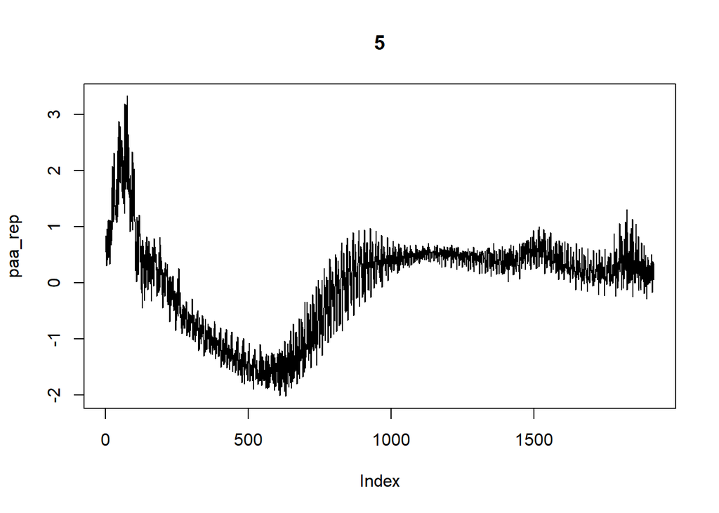

```r
traindata = traindata_reader('ECG200')
trainclass = trainclass_reader('ECG200')
paa(1,5,traindata)
```

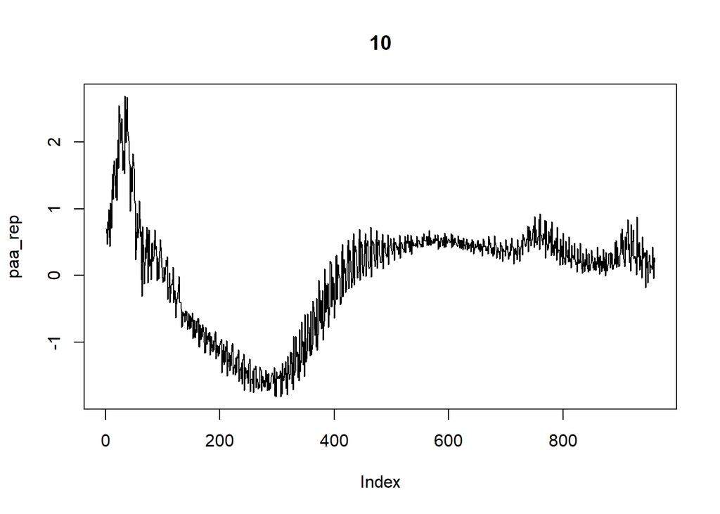

```r
paa(1,10,traindata)
```

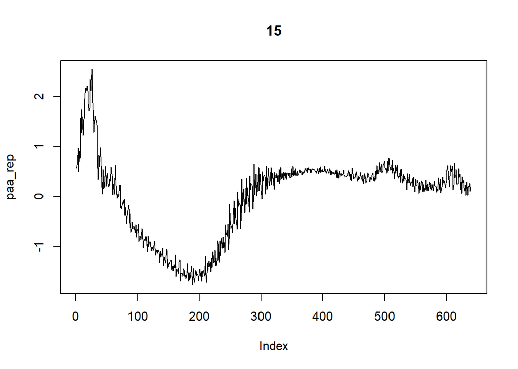

```r
paa(1,15,traindata)
```

```r
set.seed(2017402156)
cv_indices=generateCVRuns(trainclass, ntimes =nof_rep, nfold = n_fold,
                          leaveOneOut = FALSE, stratified = TRUE)
ecg_cv_indices = cv_indices
```

```r
ecg_table = tablemaker(dist_files_ECG200, trainclass, test_indices = 1:5, k_levels)
```

```
## [1] "C:/Users/aliha/Documents/IE48B - HW3/distances/ECG200_dtw_itakura_10.csv"
## [1] "C:/Users/aliha/Documents/IE48B - HW3/distances/ECG200_dtw_itakura_20.csv"
## [1] "C:/Users/aliha/Documents/IE48B - HW3/distances/ECG200_dtw_raw.csv"
## [1] "C:/Users/aliha/Documents/IE48B - HW3/distances/ECG200_dtw_sakoe_10.csv"
## [1] "C:/Users/aliha/Documents/IE48B - HW3/distances/ECG200_dtw_sakoe_20.csv"
## [1] "C:/Users/aliha/Documents/IE48B - HW3/distances/ECG200_erp_gap_005.csv"
## [1] "C:/Users/aliha/Documents/IE48B - HW3/distances/ECG200_erp_gap_01.csv"
## [1] "C:/Users/aliha/Documents/IE48B - HW3/distances/ECG200_euc_dist.csv"
## [1] "C:/Users/aliha/Documents/IE48B - HW3/distances/ECG200_lcss_005.csv"
## [1] "C:/Users/aliha/Documents/IE48B - HW3/distances/ECG200_lcss_01.csv"
```

```r
ecg_table
```

```
##                                            approach k avg_acc  sdev_acc
##  1:                                        DTW, Raw 5   0.686 0.1277913
##  2: DTW, Window type = Sakoechiba, Window Size = 10 5   0.686 0.1399854
##  3:                            ERP, Gap Penalty = 1 5   0.680 0.1414214
##  4: DTW, Window type = Sakoechiba, Window Size = 20 5   0.676 0.1318007
##  5:                              Euclidean Distance 3   0.674 0.1626440
##  6:    DTW, Window type = Itakura, Window Size = 10 5   0.674 0.1157231
##  7:    DTW, Window type = Itakura, Window Size = 20 5   0.674 0.1157231
##  8:                              Euclidean Distance 5   0.672 0.1457423
##  9:                          ERP, Gap Penalty = 0.5 5   0.638 0.1383430
## 10: DTW, Window type = Sakoechiba, Window Size = 10 3   0.638 0.1426999
## 11: DTW, Window type = Sakoechiba, Window Size = 20 3   0.636 0.1467470
## 12:                          ERP, Gap Penalty = 0.5 3   0.636 0.1351643
## 13:    DTW, Window type = Itakura, Window Size = 10 3   0.636 0.1453497
## 14:    DTW, Window type = Itakura, Window Size = 20 3   0.636 0.1453497
```

[output cut: 49 more lines]

Please note that this table was created for ECG200 dataset. For the selected dataset, the best approach seems to use DTW method with 5 nearest neighbours without additional parameters.

# Ham

## Visualization

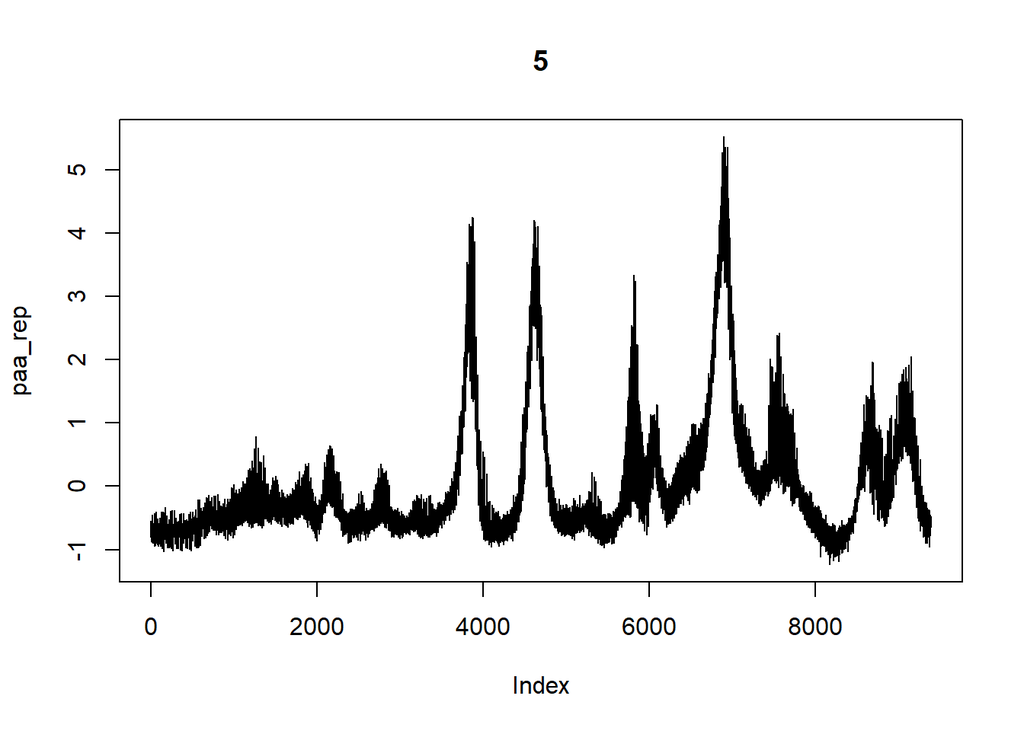

```r
traindata = traindata_reader('Ham')
trainclass = trainclass_reader('Ham')
paa(1, 5, traindata)
```

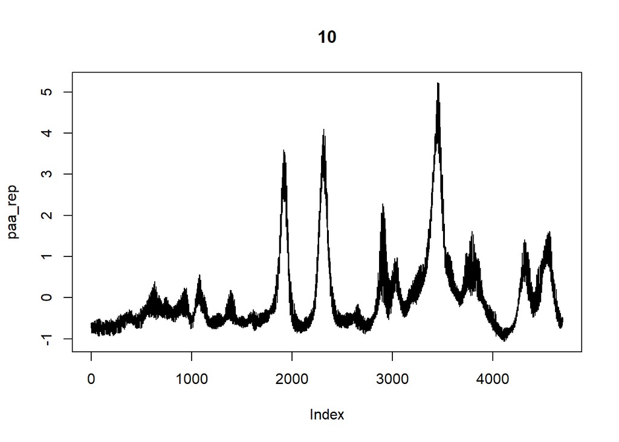

```r
paa(1,10,traindata)
```

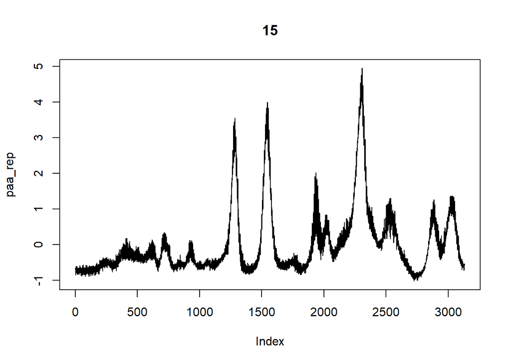

```r
paa(1,15,traindata)
```

```r
set.seed(2017402156)
cv_indices=generateCVRuns(trainclass, ntimes =nof_rep, nfold = n_fold,
                          leaveOneOut = FALSE, stratified = TRUE)
ham_cv_indices = cv_indices
```

```r
ham_table = tablemaker(dist_files_Ham, trainclass, test_indices = 1:5, k_levels)
```

```
## [1] "C:/Users/aliha/Documents/IE48B - HW3/distances/Ham_dtw_itakura_10.csv"
## [1] "C:/Users/aliha/Documents/IE48B - HW3/distances/Ham_dtw_itakura_20.csv"
## [1] "C:/Users/aliha/Documents/IE48B - HW3/distances/Ham_dtw_raw.csv"
## [1] "C:/Users/aliha/Documents/IE48B - HW3/distances/Ham_dtw_sakoe_10.csv"
## [1] "C:/Users/aliha/Documents/IE48B - HW3/distances/Ham_dtw_sakoe_20.csv"
## [1] "C:/Users/aliha/Documents/IE48B - HW3/distances/Ham_erp_gap_005.csv"
## [1] "C:/Users/aliha/Documents/IE48B - HW3/distances/Ham_erp_gap_01.csv"
## [1] "C:/Users/aliha/Documents/IE48B - HW3/distances/Ham_euc_dist.csv"
## [1] "C:/Users/aliha/Documents/IE48B - HW3/distances/Ham_lcss_005.csv"
## [1] "C:/Users/aliha/Documents/IE48B - HW3/distances/Ham_lcss_01.csv"
```

```r
ham_table
```

```
##                                            approach k   avg_acc   sdev_acc
##  1:                              Euclidean Distance 1 0.8592727 0.11117733
##  2: DTW, Window type = Sakoechiba, Window Size = 20 3 0.8590909 0.11525928
##  3: DTW, Window type = Sakoechiba, Window Size = 10 5 0.8554545 0.11966741
##  4: DTW, Window type = Sakoechiba, Window Size = 20 1 0.8552727 0.11207785
##  5:    DTW, Window type = Itakura, Window Size = 10 3 0.8501818 0.11607571
##  6:    DTW, Window type = Itakura, Window Size = 20 3 0.8501818 0.11607571
##  7:                                        DTW, Raw 3 0.8501818 0.11894629
##  8: DTW, Window type = Sakoechiba, Window Size = 20 5 0.8443636 0.11971518
##  9:    DTW, Window type = Itakura, Window Size = 10 1 0.8443636 0.12899236
## 10:    DTW, Window type = Itakura, Window Size = 20 1 0.8443636 0.12899236
## 11:                                        DTW, Raw 5 0.8440000 0.12482891
## 12:                            ERP, Gap Penalty = 1 3 0.8420000 0.09909168
## 13: DTW, Window type = Sakoechiba, Window Size = 10 3 0.8418182 0.11241083
## 14:    DTW, Window type = Itakura, Window Size = 10 5 0.8329091 0.11327609
```

[output cut: 49 more lines]

Please note that this table was created for Ham dataset. For the selected dataset, the best approach seems to use euclidean distance approach with 1 nearest neighbour. Additionally, it can be seen that Sakoechiba approach is more successful compared to the Itakura approach.

# Plane

## Visualization

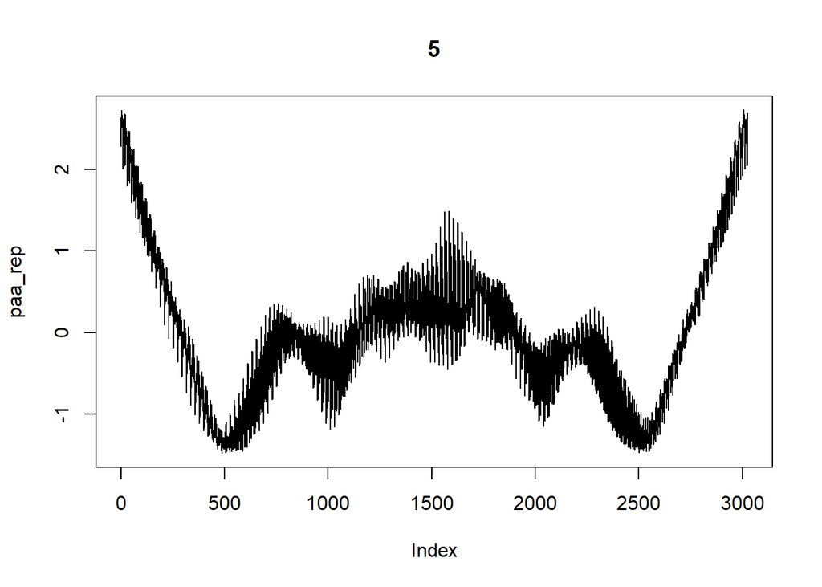

```r
traindata = traindata_reader('Plane')
trainclass = trainclass_reader('Plane')
paa(1,5,traindata)
```

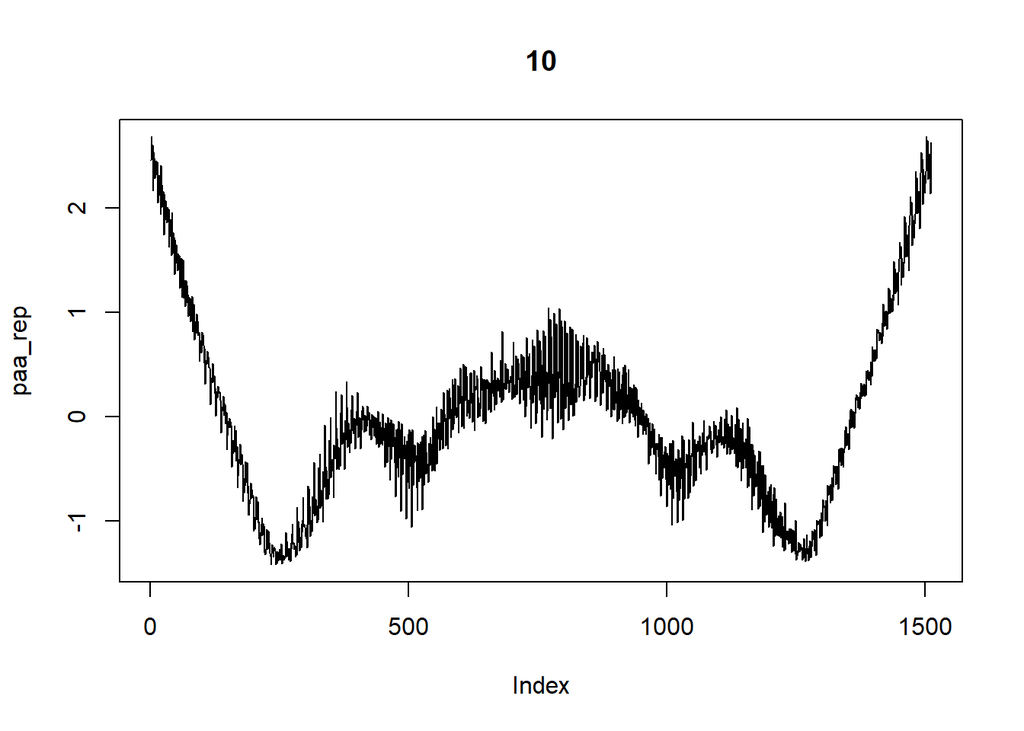

```r
paa(1,10,traindata)
```

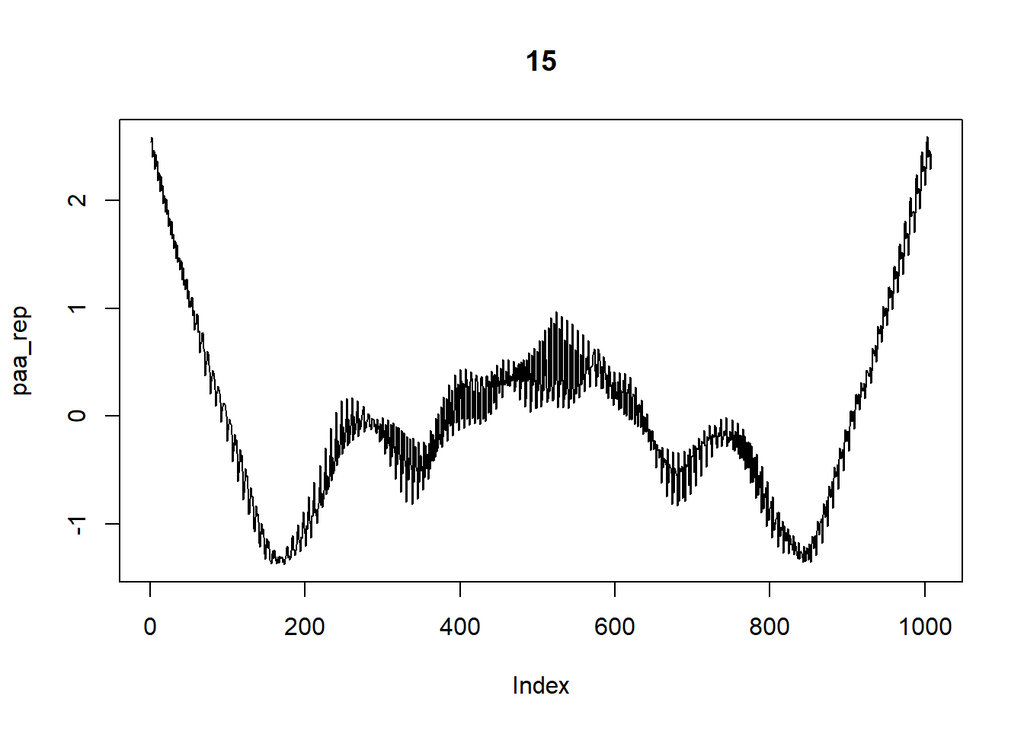

```r
paa(1,15,traindata)
```

```r
set.seed(2017402156)
cv_indices=generateCVRuns(trainclass, ntimes =nof_rep, nfold = n_fold,
                          leaveOneOut = FALSE, stratified = TRUE)
plane_cv_indices = cv_indices
```

```r
plane_table = tablemaker(dist_files_Plane, trainclass, test_indices = 1:5, k_levels)
```

```
## [1] "C:/Users/aliha/Documents/IE48B - HW3/distances/Plane_dtw_itakura_10.csv"
## [1] "C:/Users/aliha/Documents/IE48B - HW3/distances/Plane_dtw_itakura_20.csv"
## [1] "C:/Users/aliha/Documents/IE48B - HW3/distances/Plane_dtw_raw.csv"
## [1] "C:/Users/aliha/Documents/IE48B - HW3/distances/Plane_dtw_sakoe_10.csv"
## [1] "C:/Users/aliha/Documents/IE48B - HW3/distances/Plane_dtw_sakoe_20.csv"
## [1] "C:/Users/aliha/Documents/IE48B - HW3/distances/Plane_erp_gap_005.csv"
## [1] "C:/Users/aliha/Documents/IE48B - HW3/distances/Plane_erp_gap_01.csv"
## [1] "C:/Users/aliha/Documents/IE48B - HW3/distances/Plane_euc_dist.csv"
## [1] "C:/Users/aliha/Documents/IE48B - HW3/distances/Plane_lcss_005.csv"
## [1] "C:/Users/aliha/Documents/IE48B - HW3/distances/Plane_lcss_01.csv"
```

```r
plane_table
```

```
##                                            approach k   avg_acc   sdev_acc
##  1:                              Euclidean Distance 5 0.2370909 0.16942792
##  2:                          ERP, Gap Penalty = 0.5 5 0.2241818 0.17754354
##  3:    DTW, Window type = Itakura, Window Size = 10 3 0.2207273 0.15555211
##  4:    DTW, Window type = Itakura, Window Size = 20 3 0.2207273 0.15555211
##  5: DTW, Window type = Sakoechiba, Window Size = 10 3 0.2207273 0.15555211
##  6:                                        DTW, Raw 3 0.2189091 0.15217366
##  7: DTW, Window type = Sakoechiba, Window Size = 20 3 0.2189091 0.15217366
##  8:    DTW, Window type = Itakura, Window Size = 10 1 0.2170909 0.15643438
##  9:    DTW, Window type = Itakura, Window Size = 20 1 0.2170909 0.15643438
## 10:                                        DTW, Raw 1 0.2170909 0.15643438
## 11: DTW, Window type = Sakoechiba, Window Size = 10 1 0.2170909 0.15643438
## 12: DTW, Window type = Sakoechiba, Window Size = 20 1 0.2170909 0.15643438
## 13:    DTW, Window type = Itakura, Window Size = 10 5 0.2169091 0.17630806
## 14:    DTW, Window type = Itakura, Window Size = 20 5 0.2169091 0.17630806
```

[output cut: 49 more lines]

Please note that this table was created for Plane dataset. For the selected dataset, the best approach seems to use euclidean distance with 5 nearest neighbours.

# Trace

## Visualization

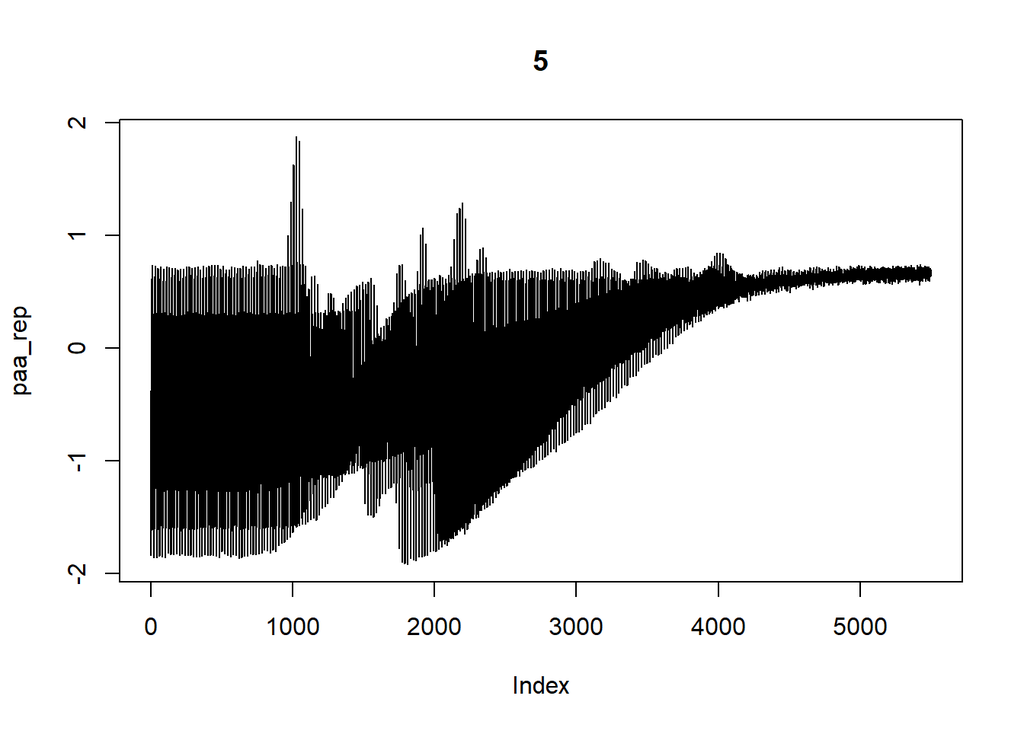

```r
traindata = traindata_reader('Trace')
trainclass = trainclass_reader('Trace')
paa(1,5,traindata)
```

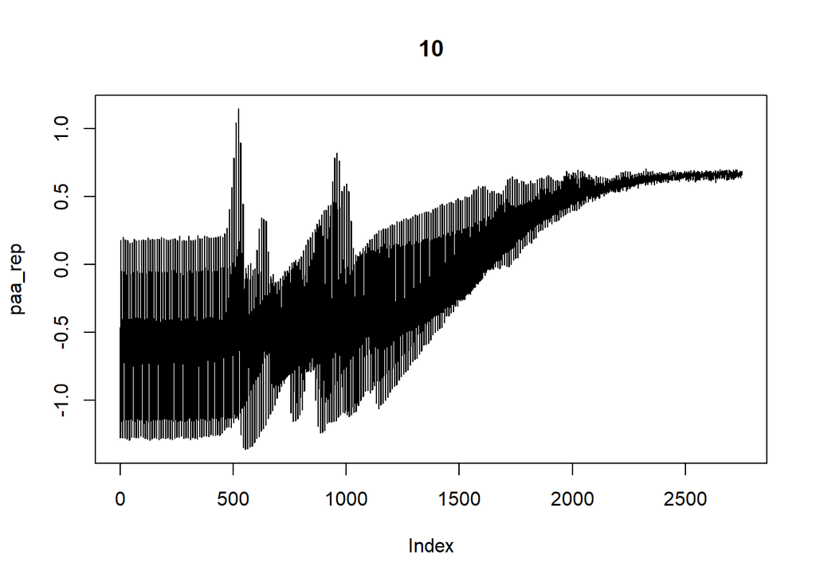

```r
paa(1,10,traindata)
```

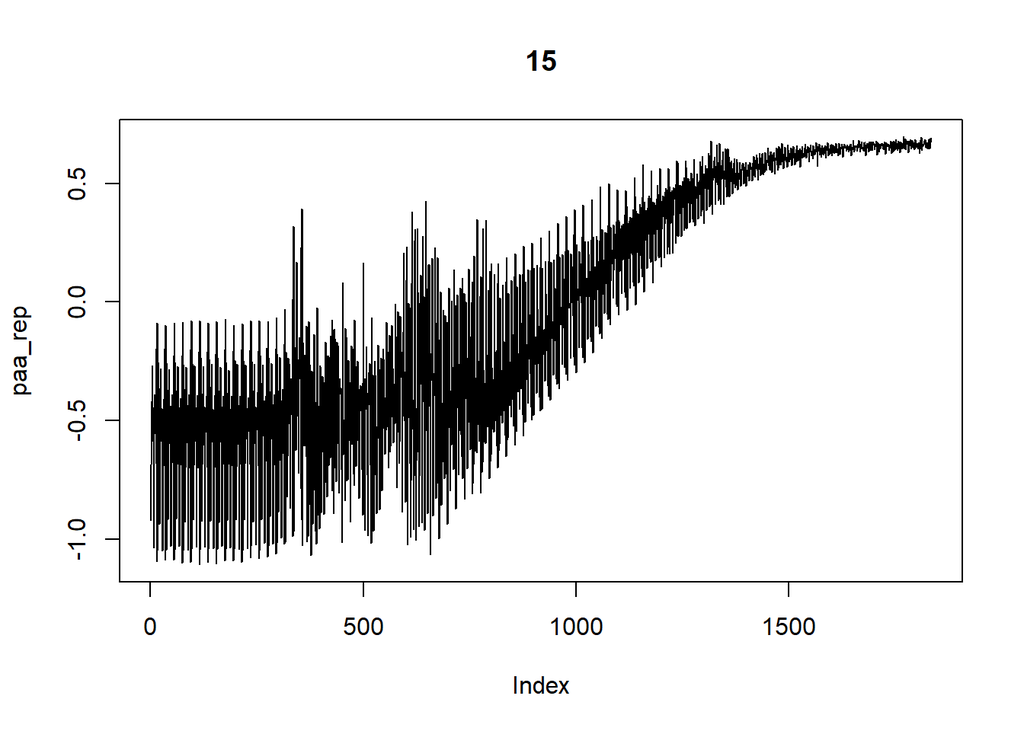

```r
paa(1,15,traindata)
```

```r
set.seed(2017402156)
cv_indices=generateCVRuns(trainclass, ntimes =nof_rep, nfold = n_fold,
                          leaveOneOut = FALSE, stratified = TRUE)
```

```r
trace_table = tablemaker(dist_files_Trace,trainclass, test_indices = 1:5, k_levels)
```

```
## [1] "C:/Users/aliha/Documents/IE48B - HW3/distances/Trace_dtw_itakura_10.csv"
## [1] "C:/Users/aliha/Documents/IE48B - HW3/distances/Trace_dtw_itakura_20.csv"
## [1] "C:/Users/aliha/Documents/IE48B - HW3/distances/Trace_dtw_raw.csv"
## [1] "C:/Users/aliha/Documents/IE48B - HW3/distances/Trace_dtw_sakoe_10.csv"
## [1] "C:/Users/aliha/Documents/IE48B - HW3/distances/Trace_dtw_sakoe_20.csv"
## [1] "C:/Users/aliha/Documents/IE48B - HW3/distances/Trace_erp_gap_005.csv"
## [1] "C:/Users/aliha/Documents/IE48B - HW3/distances/Trace_erp_gap_01.csv"
## [1] "C:/Users/aliha/Documents/IE48B - HW3/distances/Trace_euc_dist.csv"
## [1] "C:/Users/aliha/Documents/IE48B - HW3/distances/Trace_lcss_005.csv"
## [1] "C:/Users/aliha/Documents/IE48B - HW3/distances/Trace_lcss_01.csv"
```

```r
trace_table
```

```
##                                            approach k avg_acc   sdev_acc
##  1: DTW, Window type = Sakoechiba, Window Size = 10 3   0.352 0.15938658
##  2: DTW, Window type = Sakoechiba, Window Size = 20 5   0.352 0.16932037
##  3: DTW, Window type = Sakoechiba, Window Size = 20 1   0.352 0.15285047
##  4: DTW, Window type = Sakoechiba, Window Size = 20 3   0.350 0.15939938
##  5:                             LCSS, epsilon = 0.1 3   0.346 0.08854838
##  6:                            LCSS, epsilon = 0.05 5   0.342 0.10707617
##  7: DTW, Window type = Sakoechiba, Window Size = 10 1   0.340 0.14982984
##  8:                          ERP, Gap Penalty = 0.5 5   0.338 0.15238244
##  9:                            ERP, Gap Penalty = 1 5   0.334 0.13187811
## 10:                             LCSS, epsilon = 0.1 1   0.334 0.08478063
## 11:                          ERP, Gap Penalty = 0.5 1   0.334 0.16113121
## 12:                            LCSS, epsilon = 0.05 3   0.334 0.12715088
## 13:    DTW, Window type = Itakura, Window Size = 10 3   0.332 0.16713675
## 14:    DTW, Window type = Itakura, Window Size = 20 3   0.332 0.16713675
```

[output cut: 49 more lines]

Please note that this table was created for Trace dataset. For the selected dataset, the best approach seems to use DTW method with window type Sakoechiba and window size 10, and using the nearest three neighbours.